# Quant assignment 2

Aron Lesser

9/10/2020

Test change

# Loading Data

I begin by loading the data, filtering income to be greater than 0.

```r
person_data <- read_csv("people.csv")%>%
  filter(PINCP > 0)
attach(person_data)
```

# Variables

For this assignment, I will use 5 variables:

*Categorical*

1. **HISP**: Recoded detailed Hispanic origin
2. **MIG**: Mobility status (lived here 1 year ago)

*Continuous*

3. **PINCP**: Income
4. **NP**: Number of persons in this household
5. **RNTP**: Monthly rent

I decided to exclude primary language spoken at home and age because I did not feel that they will add to my analysis moving forward.

## Continuous Variables

### Monthly Rent, Income, and Number of Persons in the Household

Using the summary function, I calculate the Median, Mean, and the 1st and 3rd quartiles.

```r
summary(RNTP)
```

```
##    Min. 1st Qu.  Median    Mean 3rd Qu.    Max.
##     4.0   540.0   800.0   882.2  1100.0  2800.0
```

```r
summary(PINCP)
```

```
##    Min. 1st Qu.  Median    Mean 3rd Qu.    Max.
##       1   11600   24000   32758   40000  564000
```

```r
summary(NP)
```

```
##    Min. 1st Qu.  Median    Mean 3rd Qu.    Max.
##   1.000   2.000   2.000   2.789   4.000  20.000
```

I then calculate the standard deviation for each variable

```r
sd(RNTP)
```

```
## [1] 488.2142
```

```r
sd(PINCP)
```

```
## [1] 40215.66
```

```r
sd(NP)
```

```
## [1] 1.711492
```

And run a T test to get the 95% confidence interval of each

T test Rent

```r
pop_mean <- t.test(RNTP)

pop_mean
```

```
##
##  One Sample t-test
##
## data:  RNTP
## t = 236.14, df = 17076, p-value < 2.2e-16
## alternative hypothesis: true mean is not equal to 0
## 95 percent confidence interval:
##  874.9043 889.5501
## sample estimates:
## mean of x
##  882.2272
```

T test Income

```r
pop_mean <- t.test(PINCP)

pop_mean
```

```
##
##  One Sample t-test
##
## data:  PINCP
## t = 106.45, df = 17076, p-value < 2.2e-16
## alternative hypothesis: true mean is not equal to 0
## 95 percent confidence interval:
##  32155.30 33361.72
## sample estimates:
## mean of x
##  32758.51
```

T test Number of Persons in Household

```r
pop_mean <- t.test(NP)

pop_mean
```

```
##
##  One Sample t-test
##
## data:  NP
## t = 212.97, df = 17076, p-value < 2.2e-16
## alternative hypothesis: true mean is not equal to 0
## 95 percent confidence interval:
##  2.763519 2.814861
## sample estimates:
## mean of x
##   2.78919
```

### Representing the Data on Histograms

Finally, I create histograms representing each continuous variables on the X axis and the number of people in the sample on the Y axis. I export it to pdf in order to use it in my submission InDesign Submission.

#### Rent

```r
pdf("Rent_People_Sample.pdf", width = 3, height = 3)

hist <- ggplot(person_data, aes(x = RNTP)) +
  geom_histogram()

hist +
  theme_tufte() +
  scale_x_continuous(name = "Amount spent on rent", limits = c(0, 3000)) +
  scale_y_continuous(name = "Number of people in sample")
dev.off()
```

#### Income

```r
pdf("income_People_Sample.pdf", width = 3.5, height = 3)
hist <- ggplot(person_data, aes(x = PINCP)) +
  geom_histogram(bins = 20)

hist +
  theme_tufte() +
scale_x_continuous((name = "Income"), label = comma, limits = c(-0, 300000))+
  scale_y_continuous(name = "Number of people in sample")
dev.off()
```

#### Number of People in Household

```r
pdf("NP_household_histogram.pdf", width = 3, height = 3)


hist <- ggplot(person_data, aes(x = NP)) +
  geom_histogram(bins=12)

hist +
  theme_tufte() +
  scale_x_continuous(name = "Number of people in each household", limits = c(0,12), breaks = c(1,3,5,7,9,11)) +
  scale_y_continuous(name = "Number of people in sample")
dev.off()
```

## Categorical Variables

### Mobility

I begin by displaying the categories for Mobility

```r
mobility <- unique(MIG_label)

mobility
```

```
## [1] "No, different house in US or Puerto Rico"
## [2] "Yes, same house (nonmovers)"
## [3] "No, outside US and Puerto Rico"
```

The I get the share of the sample in each category

```r
different_us <- t.test(MIG_label == mobility[1])
nonmovers <- t.test(MIG_label == mobility[2])
different_international <- t.test(MIG_label == mobility[3])



shares <- tibble(mobility = c("different_us",
                            "nonmovers",
                            "different_international"),
                 `Share` = c(different_us$estimate,
                            nonmovers$estimate,
                            different_international$estimate),
                 Low = c(different_us$conf.int[1],
                            nonmovers$conf.int[1],
                            different_international$conf.int[1]),
                 High = c(different_us$conf.int[2],
                            nonmovers$conf.int[2],
                            different_international$conf.int[2]))
shares
```

```
## # A tibble: 3 x 4
##   mobility                  Share     Low   High
##   <chr>                     <dbl>   <dbl>  <dbl>
## 1 different_us            0.257   0.251   0.264
## 2 nonmovers               0.734   0.727   0.741
## 3 different_international 0.00878 0.00738 0.0102
```

I also illustrated the results on a bar chart, just to familiarize myself with this type of visualization

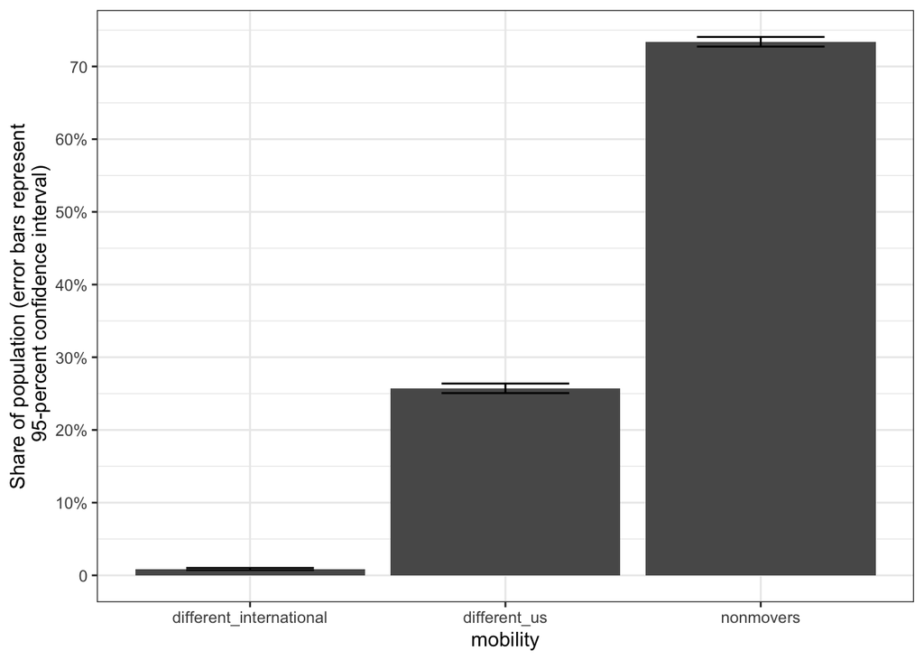

```r
ggplot(shares, aes(x = mobility, y = Share, ymin = Low, ymax = High)) +
  geom_bar(stat = "identity") +
  geom_errorbar(width = 0.5) +
  theme_bw() +
  scale_y_continuous(name = "Share of population (error bars represent\n 95-percent confidence interval)",
                     breaks = c(0, 0.1, 0.2, 0.3, 0.4, 0.5, 0.6, 0.7, 0.8),
                     labels = c("0", "10%", "20%", "30%", "40%", "50%", "60%", "70", "80"))
```

### Ethnicity of Hispanic Origin

I repet the process to look at the label categories for Hispanic Origin

```r
h_origin <- unique(HISP_label)

h_origin
```

```
##  [1] "Not Spanish/Hispanic/Latino"       "Dominican"
##  [3] "Guatemalan"                        "Mexican"
##  [5] "Salvadoran"                        "Ecuadorian"
##  [7] "Puerto Rican"                      "Colombian"
##  [9] "Panamanian"                        "Cuban"
## [11] "Honduran"                          "Peruvian"
## [13] "Spaniard"                          "Venezuelan"
## [15] "Uruguayan"                         "Nicaraguan"
## [17] "All Other Spanish/Hispanic/Latino" "Costa Rican"
## [19] "Other Central American"            "Argentinean"
## [21] "Chilean"                           "Other South American"
## [23] "Paraguayan"
```

I then get the share of the sample in each category

```r
Not_Spanish_Hispanic_Latino <- t.test(HISP_label == h_origin[1])
Dominican <- t.test(HISP_label == h_origin[2])
Guatemalan <- t.test(HISP_label == h_origin[3])
Mexican <-  t.test(HISP_label == h_origin[4])
Salvadoran <-  t.test(HISP_label == h_origin[5])
Ecuadorian <-  t.test(HISP_label == h_origin[6])
Puerto_Rican <-  t.test(HISP_label == h_origin[7])
All_other_latino <-  t.test(HISP_label == h_origin[8])
Colombian <-  t.test(HISP_label == h_origin[9])
Panamanian <-  t.test(HISP_label == h_origin[10])
Cuban <-  t.test(HISP_label == h_origin[11])
Honduran <-  t.test(HISP_label == h_origin[12])
Peruvian <-  t.test(HISP_label == h_origin[13])
Spaniard <-  t.test(HISP_label == h_origin[14])
Venezuelan <-  t.test(HISP_label == h_origin[15])
Uruguayan <-  t.test(HISP_label == h_origin[16])
Nicaraguan <-  t.test(HISP_label == h_origin[17])
Costa_Rican <-  t.test(HISP_label == h_origin[18])
Other_Central_American <-  t.test(HISP_label == h_origin[19])
Argentinian <-  t.test(HISP_label == h_origin[20])
Chilean <-  t.test(HISP_label == h_origin[21])
Paraguayan <-  t.test(HISP_label == h_origin[22])
Other_South_America <-  t.test(HISP_label == h_origin[23])


shares <- tibble(h_origin = c("Not_Spanish_Hispanic_Latino",
                              "Dominican",
                              "Guatemalan",
                              "Mexican",
                              "Salvadoran",
                              "Ecuadorian",
                              "Puerto_Rican",
                              "All_other_latino",
                              "Colombian",
                              "Panamanian",
                              "Cuban",
                              "Honduran",
                              "Peruvian",
                              "Spaniard",
                              "Venezuelan",
                              "Uruguayan",
                              "Nicaraguan",
                              "Costa_Rican",
                              "Other_Central_American",
                              "Argentinian",
                              "Chilean",
                              "Paraguayan",
                              "Other_South_America"),

                 `Share` = c(Not_Spanish_Hispanic_Latino$estimate,
                               Dominican$estimate,
                               Guatemalan$estimate,
                               Mexican$estimate,
                               Salvadoran$estimate,
                               Ecuadorian$estimate,
                               Puerto_Rican$estimate,
                               All_other_latino$estimate,
                               Colombian$estimate,
                               Panamanian$estimate,
                               Cuban$estimate,
                               Honduran$estimate,
                               Peruvian$estimate,
                               Spaniard$estimate,
                               Venezuelan$estimate,
                               Uruguayan$estimate,
                               Nicaraguan$estimate,
                               Costa_Rican$estimate,
                               Other_Central_American$estimate,
                               Argentinian$estimate,
                               Chilean$estimate,
                               Paraguayan$estimate,
                               Other_South_America$estimate),

                 Low = c(Not_Spanish_Hispanic_Latino$conf.int[1],
                               Dominican$conf.int[1],
                               Guatemalan$conf.int[1],
                               Mexican$conf.int[1],
                               Salvadoran$conf.int[1],
                               Ecuadorian$conf.int[1],
                               Puerto_Rican$conf.int[1],
                               All_other_latino$conf.int[1],
                               Colombian$conf.int[1],
                               Panamanian$conf.int[1],
                               Cuban$conf.int[1],
                               Honduran$conf.int[1],
                               Peruvian$conf.int[1],
                               Spaniard$conf.int[1],
                               Venezuelan$conf.int[1],
                               Uruguayan$conf.int[1],
                               Nicaraguan$conf.int[1],
                               Costa_Rican$conf.int[1],
                               Other_Central_American$conf.int[1],
                               Argentinian$conf.int[1],
                               Chilean$conf.int[1],
                               Paraguayan$conf.int[1],
                               Other_South_America$conf.int[1]),

                 High = c(Not_Spanish_Hispanic_Latino$conf.int[2],
                               Dominican$conf.int[2],
                               Guatemalan$conf.int[2],
                               Mexican$conf.int[2],
                               Salvadoran$conf.int[2],
                               Ecuadorian$conf.int[2],
                               Puerto_Rican$conf.int[2],
                               All_other_latino$conf.int[2],
                               Colombian$conf.int[2],
                               Panamanian$conf.int[2],
                               Cuban$conf.int[2],
                               Honduran$conf.int[2],
                               Peruvian$conf.int[2],
                               Spaniard$conf.int[2],
                               Venezuelan$conf.int[2],
                               Uruguayan$conf.int[2],
                               Nicaraguan$conf.int[2],
                               Costa_Rican$conf.int[2],
                               Other_Central_American$conf.int[2],
                               Argentinian$conf.int[2],
                               Chilean$conf.int[2],
                               Paraguayan$conf.int[2],
                               Other_South_America$conf.int[2]))
shares
```

```
## # A tibble: 23 x 4
##    h_origin                       Share      Low     High
##    <chr>                          <dbl>    <dbl>    <dbl>
##  1 Not_Spanish_Hispanic_Latino 0.900    0.895    0.904
##  2 Dominican                   0.00246  0.00172  0.00320
##  3 Guatemalan                  0.00837  0.00701  0.00974
##  4 Mexican                     0.0528   0.0495   0.0562
##  5 Salvadoran                  0.00386  0.00293  0.00480
##  6 Ecuadorian                  0.000527 0.000183 0.000871
##  7 Puerto_Rican                0.0117   0.0100   0.0133
##  8 All_other_latino            0.00386  0.00293  0.00480
##  9 Colombian                   0.000820 0.000391 0.00125
## 10 Panamanian                  0.00299  0.00217  0.00380
## # … with 13 more rows
```

# Finalizing the Submisison

To finalize the submission, I transfer the data to my InDesign layout and link the histograms. I include my discussion questions and reflections on the data in the final pdf submission.